# Análisis de las Características de Héroes y Villanos

Laurys Alvarez <3

4 de Septiembre del 2025

```r
# Cargamos el archivo .csv que usaremos
datos_heroes <- read.csv("heroes_information.csv")
```

Esta investigación está basada en un data frame de Súper Héroes y Villanos de diferentes editoriales. La data incluye características físicas como su altura, color de ojos, peso, así como están diferenciados en sus universos, ya sea por su raza, si son “Buenos”, “Malos” o “Neutrales”.

```r
# Mostraremos el data frame completo con "DT"
datatable(datos_heroes)
```

|  | X | name | Gender | Eye.color | Race | Hair.color | Height | Publisher | Skin.color | Alignment | Weight |
| --- | --- | --- | --- | --- | --- | --- | --- | --- | --- | --- | --- |
| 1 | 0 | A-Bomb | Male | yellow | Human | No Hair | 203 | Marvel Comics | - | good | 441 |
| 2 | 1 | Abe Sapien | Male | blue | Icthyo Sapien | No Hair | 191 | Dark Horse Comics | blue | good | 65 |
| 3 | 2 | Abin Sur | Male | blue | Ungaran | No Hair | 185 | DC Comics | red | good | 90 |
| 4 | 3 | Abomination | Male | green | Human / Radiation | No Hair | 203 | Marvel Comics | - | bad | 441 |
| 5 | 4 | Abraxas | Male | blue | Cosmic Entity | Black | -99 | Marvel Comics | - | bad | -99 |
| 6 | 5 | Absorbing Man | Male | blue | Human | No Hair | 193 | Marvel Comics | - | bad | 122 |
| 7 | 6 | Adam Monroe | Male | blue | - | Blond | -99 | NBC - Heroes | - | good | -99 |
| 8 | 7 | Adam Strange | Male | blue | Human | Blond | 185 | DC Comics | - | good | 88 |
| 9 | 8 | Agent 13 | Female | blue | - | Blond | 173 | Marvel Comics | - | good | 61 |
| 10 | 9 | Agent Bob | Male | brown | Human | Brown | 178 | Marvel Comics | - | good | 81 |

[output cut: 724 more lines]

## 1. Limpieza del data frame

Para el data frame a utilizar, es necesario limpiar los datos que no estén correctos, para así poder tener mejores resultados. Y conmprobamos que los números estén correctos con **summary**, esto nos dará un resumen estadístico con todas nuestras variables.

En esta investigación, los datos errados los asignaremos con un “NA”, para los análisis que haremos no estaremos usando estos datos, esto para que todos los resultados sean confiables y exactos.

```r
# Reemplazamos los datos que estén errados
datos_heroes[datos_heroes == "-99"] <- NA
# Lo que haremos acá es asignarle el "NA" a los datos errados
datos_heroes[datos_heroes == "-"] <- NA

# Comprobamos que la data está limpia con un resumen
summary(datos_heroes)
```

```
##        X             name              Gender           Eye.color
##  Min.   :  0.0   Length:734         Length:734         Length:734
##  1st Qu.:183.2   Class :character   Class :character   Class :character
##  Median :366.5   Mode  :character   Mode  :character   Mode  :character
##  Mean   :366.5
##  3rd Qu.:549.8
##  Max.   :733.0
##
##      Race            Hair.color            Height       Publisher
##  Length:734         Length:734         Min.   : 15.2   Length:734
##  Class :character   Class :character   1st Qu.:173.0   Class :character
##  Mode  :character   Mode  :character   Median :183.0   Mode  :character
##                                        Mean   :186.7
##                                        3rd Qu.:191.0
##                                        Max.   :975.0
##                                        NA's   :217
##   Skin.color         Alignment             Weight
##  Length:734         Length:734         Min.   :  2.0
##  Class :character   Class :character   1st Qu.: 61.0
##  Mode  :character   Mode  :character   Median : 81.0
##                                        Mean   :112.3
##                                        3rd Qu.:108.0
##                                        Max.   :900.0
##                                        NA's   :239
```

## 2. Definir paletas de colores

Para ofrecer una mejor visualización de los gráficos por presentar, asignaremos varias paletas de colores a este análisis

```r
# Para mejor visualización de los gráficos a presentar, le asignaré paletas de colores a este trabajo
paleta_gemas_infinito <- c("#3FA0FF","#D8152F","#FFEE99", "#BB00BB","#86FF86","#FF8F33")
paleta_hero2 <- c("#1E8E99", "#CC5800","#000000","#490092","#666666")
paleta_hero3 <- c("#A51209","#0055AA","#FFCE45","#44B05B", "#120976")
```

## 3. Relaciones entre nuestras variables

Con un data frame que trata de Súper Héroes, las variables son miles. Pero, nos concentraremos en observar las correlaciones entre la misma data. Veremos si unos datos afectan a otros y el motivo, así mismo como están estas distribuciones de datos.

### ¿Cómo se distribuye el género en los Héroes?

```r
Dist_gender <- datos_heroes %>%
  # Filtramos los NA
  filter(!is.na(Gender)) %>%
  group_by(Gender) %>%
  summarise(count = n())
datatable(Dist_gender,
          caption = "Distribución de Género entre Héroes")
```

|  | Gender | count |
| --- | --- | --- |
| 1 | Female | 200 |
| 2 | Male | 505 |

Podemos observar como hay mayor población masculina que femenina, ahora, nos preguntamos

### ¿El género está relacionada con su altura?

```r
Relation_gender <- datos_heroes %>%
  # Filtramos los NA
  filter(!is.na(Gender)) %>%
group_by(Gender) %>%
summarise(Promedio_Altura = mean(Height, na.rm = TRUE),
          Promedio_Mediana = median(Height, na.rm = TRUE),
          num_heroes = n(), groups = "drop")
datatable(Relation_gender,
          caption = "Relación de la altura con los géneros")
```

|  | Gender | Promedio_Altura | Promedio_Mediana | num_heroes | groups |
| --- | --- | --- | --- | --- | --- |
| 1 | Female | 174.6840277777778 | 170 | 200 | drop |
| 2 | Male | 191.9748603351955 | 185 | 505 | drop |

Gráfico de barras, para poder visualizar mejor los resultados

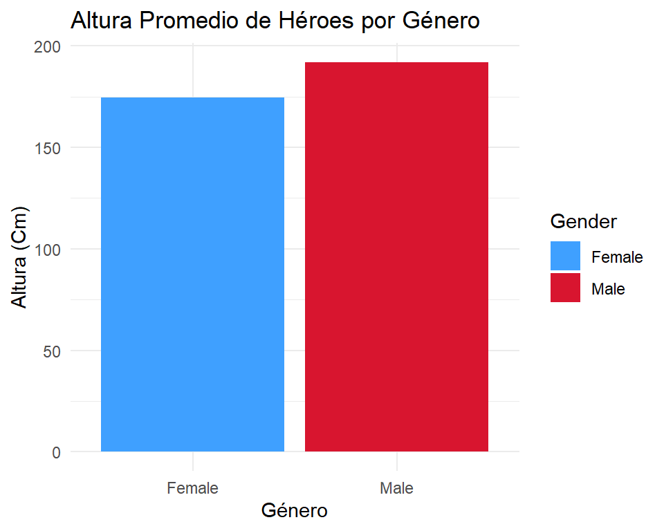

```r
ggplot(Relation_gender, aes(x = Gender, y = Promedio_Altura, fill = Gender)) +
  geom_bar(stat = "identity") +
  scale_fill_manual(values = paleta_gemas_infinito) +
  labs(title = "Altura Promedio de Héroes por Género", x = "Género", y = "Altura (Cm)") +
  theme_minimal()
```

Observamos que, la altura de los súper héroes en general **Sí** se encuentra relacionada por su género, siendo los personajes masculinos notablemente más altos que los personajes femeninos. Estos resultados pueden atribuirse a que generalmente los hombres (y más héroes) han sido más grandes y altos que las mujeres, por estereotipos o por diseño del personaje.

Seguimos con las relaciones entre variables

## 4. Marvel VS DC

[figure not shown]

Me pregunto, si la altura de los héroes se encuentra relacionada con el género, ¿que diferencias podrían haber entre Marvel y DC?

### ¿El género se verá relacionado con el Publisher (Editorial)?

```r
generop <- datos_heroes %>%
  #Filtro solamente Marvel y DC, ya que en eso me estoy enfocando
  filter(Publisher %in% c("Marvel Comics", "DC Comics")) %>%
  # Filtramos los NA
  filter(!is.na(Gender) & !is.na(Publisher)) %>%
  group_by(Gender, Publisher) %>%
  count() %>%
arrange(desc(n))
datatable(generop, caption = "Relación del Género y las Editoriales")
```

|  | Gender | Publisher | n |
| --- | --- | --- | --- |
| 1 | Male | Marvel Comics | 252 |
| 2 | Male | DC Comics | 153 |
| 3 | Female | Marvel Comics | 111 |
| 4 | Female | DC Comics | 61 |

Gráfica de Barras entre Marvel y DC

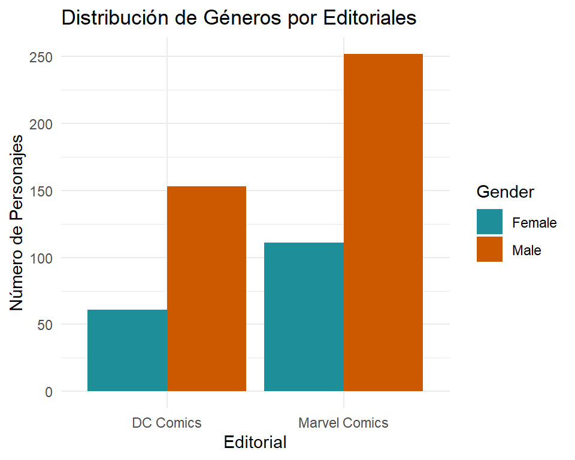

```r
ggplot(generop, aes(x = Publisher, y = n, fill = Gender)) +
  geom_bar(stat = "identity",position = "dodge") +
  scale_fill_manual(values = paleta_hero2) +
  labs(title = "Distribución de Géneros por Editoriales", x = "Editorial", y = "Número de Personajes") +
  theme_minimal()
```

Si seguimos relacionando Marvel y DC, creo otra incógnita:

### ¿En que Editorial hay más villanos o más héroes?

```r
alignmentd <- datos_heroes %>%
  filter(Publisher %in% c("Marvel Comics", "DC Comics")) %>%
  # Filtramos los NA
  filter(!is.na(Publisher) & !is.na(Alignment)) %>%
  group_by(Publisher, Alignment) %>%
  count() %>%
  arrange(desc(n))
datatable(alignmentd, caption = "Villanos y Héroes en cada Editorial")
```

|  | Publisher | Alignment | n |
| --- | --- | --- | --- |
| 1 | Marvel Comics | good | 259 |
| 2 | DC Comics | good | 142 |
| 3 | Marvel Comics | bad | 115 |
| 4 | DC Comics | bad | 59 |
| 5 | DC Comics | neutral | 13 |
| 6 | Marvel Comics | neutral | 11 |

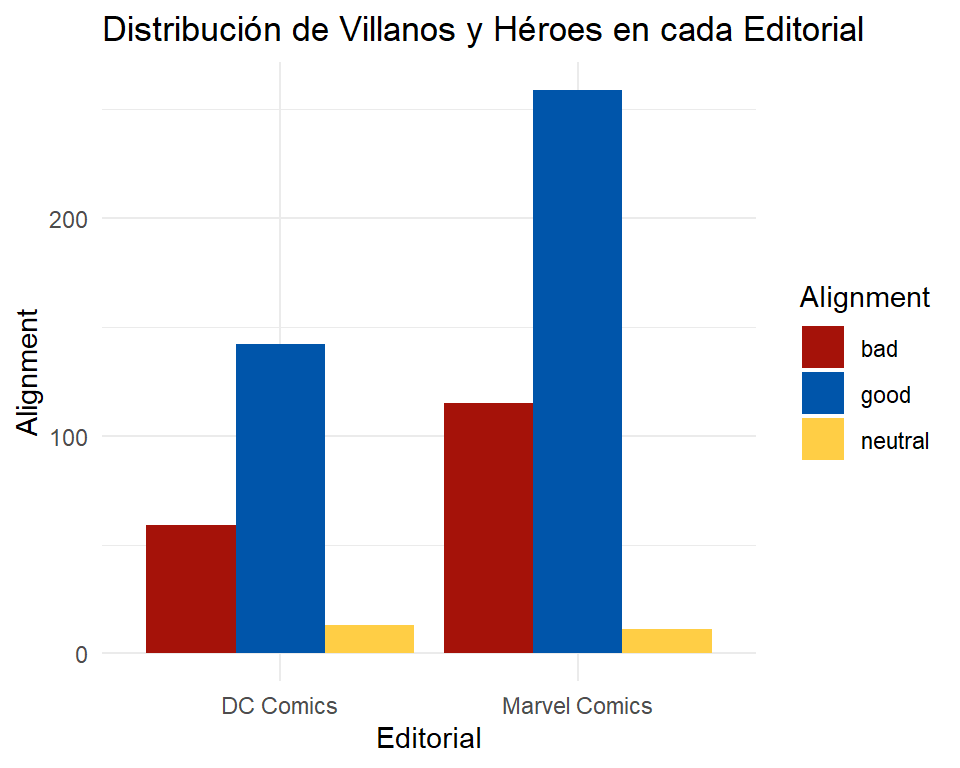

```r
ggplot(alignmentd, aes(x = Publisher, y = n, fill = Alignment)) +
  geom_bar(stat = "identity",position = "dodge") +
  scale_fill_manual(values = paleta_hero3) +
  labs(title = "Distribución de Villanos y Héroes en cada Editorial", x = "Editorial", y = "Alignment") +
  theme_minimal()
```

Analizando la data, demuestra que tanto como en Marvel y DC, los personajes buenos (good), son mayores en cantidad que los malos (bad), así como los neutrales (neutral). Podemos explicar estos resultados ya que, en la mayoría de comics o películas, la historia se centra en el bueno, o en el grupo de los buenos. Sus historias es más larga, profunda, generalmente, por cada villano hay un grupo de buenos.

Sin embargo, tenemos que tener en cuenta la proporción de Editoriales, Marvel tiene mas personajes que DC. Tomando esto en cuenta igualmente podríamos decir que Marvel tiene una mayor proporción de villanos en comparación con sus héroes, esto nos puede indicar que cada Editorial tiene un enfoque en sus historias diferentes, DC enfocándose más en sus héroes y Marvel en su amplio catálogo de villanos.

## Editoriales vs Características

Me pregunto, como estarán estos mundos ficticios distribuidos? Es decir,

### ¿Que clases de razas habrán en estas 2 editoriales?

A continuación, mostraré las razas en el Universo Marvel

```r
race_data <- datos_heroes %>%
  #Filtro solamente Marvel, ya que iremos primero por esta Editorial
  filter(Publisher %in% c("Marvel Comics")) %>%
  # Filtramos los NA
  filter(!is.na(Race)) %>%
  group_by(Race) %>%
  count(name = "Conteo_Marvel") %>%
  ungroup() %>%
  arrange(desc(Conteo_Marvel))

# Agruparé las razas con menos de 4 personajes en una categoría "Otras Razas"
race_conteo_limpio <- race_data %>%
  mutate(Race = ifelse(Conteo_Marvel < 4, "Otras Razas", Race)) %>%
  group_by(Race) %>%
  summarise(Conteo_Marvel = sum(Conteo_Marvel), .groups = 'drop')
datatable(race_conteo_limpio, caption = "Tipos de razas en Marvel")
```

|  | Race | Conteo_Marvel |
| --- | --- | --- |
| 1 | Alien | 5 |
| 2 | Asgardian | 5 |
| 3 | Cosmic Entity | 4 |
| 4 | Cyborg | 4 |
| 5 | God / Eternal | 4 |
| 6 | Human | 85 |
| 7 | Human / Radiation | 10 |
| 8 | Inhuman | 4 |
| 9 | Mutant | 56 |
| 10 | Otras Razas | 29 |

[output cut: 1 more lines]

[figure not shown]

```r
ggplot(race_conteo_limpio, aes(x = "", y = "", fill = Race)) +
  geom_bar(stat = "identity", width = 1) +
  coord_polar("y", start = 0) +
  labs(title = "Distribución de Razas en Marvel") +
  # Añadir etiquetas con los porcentajes
  geom_text(aes(label = paste0(round(Conteo_Marvel / sum(Conteo_Marvel) * 100), "%")),
            position = position_stack(vjust = 0.5)) +
  theme_minimal()
```

Y a su vez, las razas del Universo DC

```r
race_data_2 <- datos_heroes %>%
  #Filtro solamente DC, ya que iremos primero por esta Editorial
  filter(Publisher %in% c("DC Comics")) %>%
  # Filtramos los NA
  filter(!is.na(Race)) %>%
  group_by(Race) %>%
  count(name = "Conteo_DC") %>%
  ungroup() %>%
  arrange(desc(Conteo_DC))

# Agruparé las razas con menos de 4 personajes en una categoría "Otras Razas"
Raza_DC <- race_data_2 %>%
  mutate(Race = ifelse(Conteo_DC < 4, "Otras Razas", Race)) %>%
  group_by(Race) %>%
  summarise(Conteo_DC = sum(Conteo_DC), .groups = 'drop')
datatable(Raza_DC, caption = "Tipos de razas en DC")
```

|  | Race | Conteo_DC |
| --- | --- | --- |
| 1 | Android | 4 |
| 2 | Atlantean | 4 |
| 3 | God / Eternal | 7 |
| 4 | Human | 91 |
| 5 | Kryptonian | 7 |
| 6 | Otras Razas | 31 |

[figure not shown]

```r
ggplot(Raza_DC, aes(x = "", y = "", fill = Race)) +
  geom_bar(stat = "identity", width = 1) +
  coord_polar("y", start = 0) +
  labs(title = "Distribución de Razas en DC") +
  # Añadir etiquetas con los porcentajes
  geom_text(aes(label = paste0(round(Conteo_DC / sum(Conteo_DC) * 100), "%")),
            position = position_stack(vjust = 0.5)) +
  theme_minimal()
```

El análisis de estos resultados, demostrados en gráficas de torta y sus data frame, nos indican varias cosas:

Primeramente, tenemos que tener en cuenta las proporciones de personajes por Editorial, en Marvel hay mas personajes que DC. Aún así, podemos observar que en Marvel hay mayor diversidad de Razas, y aunque no sean númericamente amplios, en conjunto aportan variedad a esta Editorial. Pero, casi la mitad de estos personajes son Humanos, ya que la mayoría de personajes tienen orígenes humanos antes de ser Héroes o Villanos.

En el Universo DC, los resultados implican que más de la mitad de personajes son Humanos, pero, también vemos que hay menos razas que en Marvel, podemos influir esto a que esta Editorial se centra menos en explorar múltiples universos que su rival Marvel.

En resumen, las 2 editoriales cuentan con mas personajes humanos, pero aún así con mucha variedad de personajes de otros planetas y universos, fomentando su expansión y variedad de historias que nos pueden dar gracias a estos personajes.